# `ggplot` 연습문제

## 6. 아래 코드를 실행해보세요. 어떤점을 새로 알게되었나요?

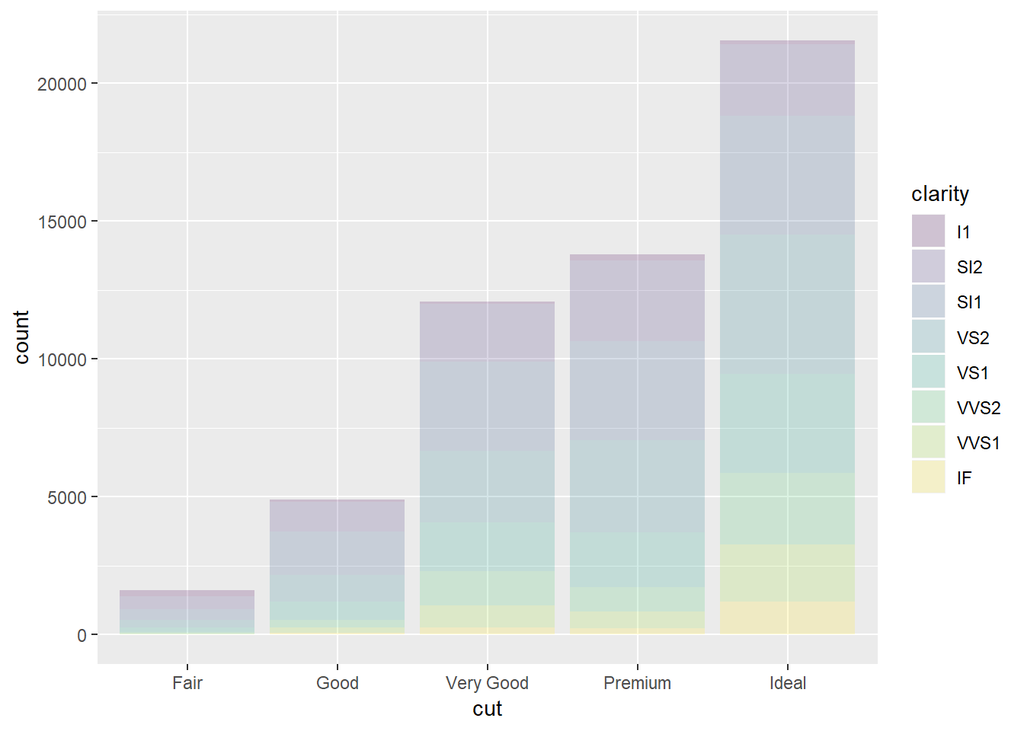

```r
ggplot(data = diamonds, mapping = aes(x = cut, fill = clarity)) +
  geom_bar(alpha = 1/5)
```

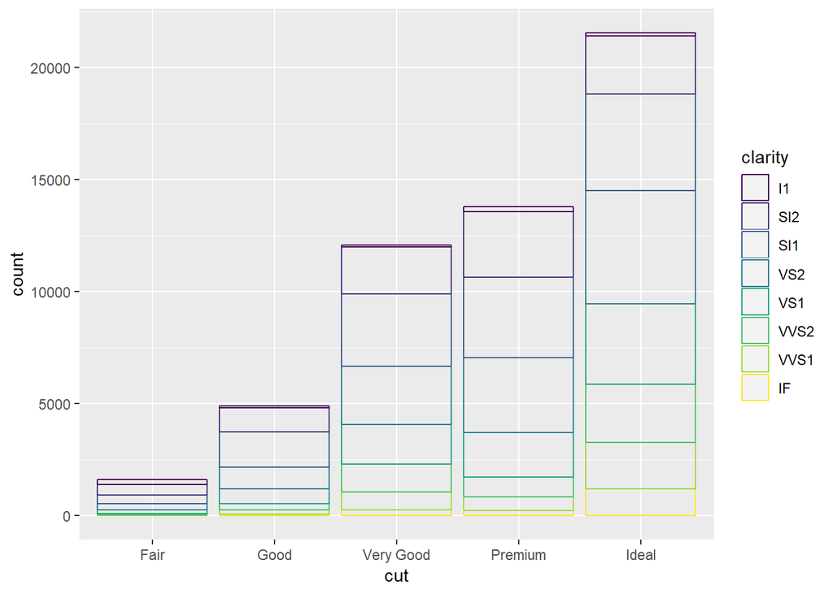

```r
ggplot(data = diamonds, mapping = aes(x = cut, colour = clarity)) +
  geom_bar(fill = NA)
```

- `alpha`와 `fill`을 `aes()`에 넣지 않으면 그림을 전체적으로 바꿀 수 있습니다.
- 투명한 다이아몬드를 표현하는데에 적절한 것 같지 않나요?

## 7. `labs()` 함수는 레이블을 만듭니다. `? labs`를 콘솔에 쳐서 읽어보세요. 이를 이용해서 그래프의 제목, x축, y축에 글자를 넣어보세요.

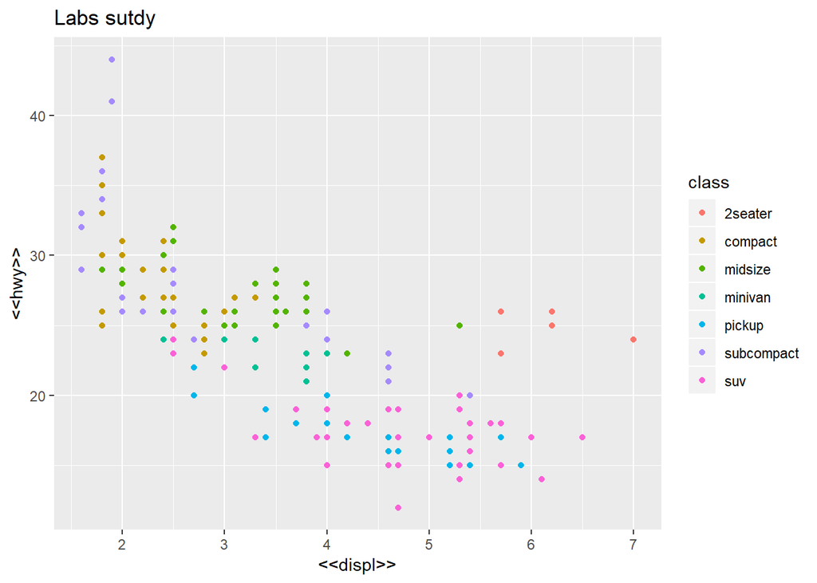

```r
a <- ggplot(data=mpg) +
  geom_point (mapping=aes(x=displ, y=hwy, color=class))
a + labs(title = "Labs sutdy", x = "<<displ>>", y = "<<hwy>>")
```